# Bank Churn Prediction

### Background

Businesses like banks that provide service have to worry about the problem of 'Churn' i.e. customers leaving and joining another service provider. It is important to understand which aspects of the service influence a customer's decision in this regard. Management can concentrate efforts on the improvement of service, keeping in mind these priorities.

##### Objective:

Given a Bank customer, build a neural network-based classifier that can determine whether they will leave or not in the next 6 months.

### Data Context

1. CustomerId: Unique ID which is assigned to each customer
2. Surname: Last name of the customer
3. CreditScore: It defines the credit history of the customer.
4. Geography: A customer’s location
5. Gender: It defines the Gender of the customer
6. Age: Age of the customer
7. Tenure: Number of years for which the customer has been with the bank
8. NumOfProducts: It refers to the number of products that a customer has purchased through the bank.
9. Balance: Account balance
10. HasCrCard: It is a categorical variable that decides whether the customer has a credit card or not.
11. EstimatedSalary: Estimated salary
12. isActiveMember: It is a categorical variable that decides whether the customer is an active member of the bank or not ( Active member in the sense, using bank products regularly, making transactions, etc )
13. Exited: It is a categorical variable that decides whether the customer left the bank within six months or not. It can take two values: 0=No ( Customer did not leave the bank ), 1=Yes ( Customer left the bank )

#### Importing all the required packages for the project:

```python
import pandas as pd  # importing Pandas for dataset import
import matplotlib.pyplot as plt  # importing for basic visualization and seaborn
import seaborn as sns  # importing for better visualization features
import warnings  # importing to suppress the warnings of deprecated features
import numpy as np  # importing numpy
warnings.filterwarnings("ignore")  # suppress the warnings
pd.set_option("display.max_columns", None) # Removes the limit for the number of displayed columns
pd.set_option("display.max_rows", 200) # Sets the limit for the number of displayed rows
from sklearn.metrics import accuracy_score, confusion_matrix, precision_score, recall_score, f1_score, precision_recall_curve, auc
from sklearn.model_selection import train_test_split
import keras
import tensorflow as tf
from keras import backend as K
from keras.models import Sequential
from keras.layers import Dense, Dropout
from tensorflow.keras.optimizers import Adam
```

```python
#importing tensorflow
import tensorflow as tf
print(tf.__version__)
```

```
2.6.0
```

#### Read in the dataset using pandas

```python
# importing dataset stored in csv file and setting 1st cloumn as index
df = pd.read_csv(
    r"C:\Users\user\Desktop\AI_ML_Austin\notebook prog files\ProjectWork7\bank.csv"
)
# creating a copy of the data so that original data remains unchanged
bankdf1 = df.copy()
```

#### To assess the data set (Top 10)

```python
bankdf1.head(10)  # display top 10 rows
```

|  | RowNumber | CustomerId | Surname | CreditScore | Geography | Gender | Age | Tenure | Balance | NumOfProducts | HasCrCard | IsActiveMember | EstimatedSalary | Exited |
| --- | --- | --- | --- | --- | --- | --- | --- | --- | --- | --- | --- | --- | --- | --- |
| 0 | 1 | 15634602 | Hargrave | 619 | France | Female | 42 | 2 | 0.00 | 1 | 1 | 1 | 101348.88 | 1 |
| 1 | 2 | 15647311 | Hill | 608 | Spain | Female | 41 | 1 | 83807.86 | 1 | 0 | 1 | 112542.58 | 0 |
| 2 | 3 | 15619304 | Onio | 502 | France | Female | 42 | 8 | 159660.80 | 3 | 1 | 0 | 113931.57 | 1 |
| 3 | 4 | 15701354 | Boni | 699 | France | Female | 39 | 1 | 0.00 | 2 | 0 | 0 | 93826.63 | 0 |
| 4 | 5 | 15737888 | Mitchell | 850 | Spain | Female | 43 | 2 | 125510.82 | 1 | 1 | 1 | 79084.10 | 0 |
| 5 | 6 | 15574012 | Chu | 645 | Spain | Male | 44 | 8 | 113755.78 | 2 | 1 | 0 | 149756.71 | 1 |
| 6 | 7 | 15592531 | Bartlett | 822 | France | Male | 50 | 7 | 0.00 | 2 | 1 | 1 | 10062.80 | 0 |
| 7 | 8 | 15656148 | Obinna | 376 | Germany | Female | 29 | 4 | 115046.74 | 4 | 1 | 0 | 119346.88 | 1 |
| 8 | 9 | 15792365 | He | 501 | France | Male | 44 | 4 | 142051.07 | 2 | 0 | 1 | 74940.50 | 0 |
| 9 | 10 | 15592389 | H? | 684 | France | Male | 27 | 2 | 134603.88 | 1 | 1 | 1 | 71725.73 | 0 |

Checking random rows

```python
np.random.seed(
    1
)  # random set with seed 1, so the same set of random values can be generated everytime
bankdf1.sample(n=20)  # Print 20 random rows to check the dataset
```

|  | RowNumber | CustomerId | Surname | CreditScore | Geography | Gender | Age | Tenure | Balance | NumOfProducts | HasCrCard | IsActiveMember | EstimatedSalary | Exited |
| --- | --- | --- | --- | --- | --- | --- | --- | --- | --- | --- | --- | --- | --- | --- |
| 9953 | 9954 | 15655952 | Burke | 550 | France | Male | 47 | 2 | 0.00 | 2 | 1 | 1 | 97057.28 | 0 |
| 3850 | 3851 | 15775293 | Stephenson | 680 | France | Male | 34 | 3 | 143292.95 | 1 | 1 | 0 | 66526.01 | 0 |
| 4962 | 4963 | 15665088 | Gordon | 531 | France | Female | 42 | 2 | 0.00 | 2 | 0 | 1 | 90537.47 | 0 |
| 3886 | 3887 | 15720941 | Tien | 710 | Germany | Male | 34 | 8 | 147833.30 | 2 | 0 | 1 | 1561.58 | 0 |
| 5437 | 5438 | 15733476 | Gonzalez | 543 | Germany | Male | 30 | 6 | 73481.05 | 1 | 1 | 1 | 176692.65 | 0 |
| 8517 | 8518 | 15671800 | Robinson | 688 | France | Male | 20 | 8 | 137624.40 | 2 | 1 | 1 | 197582.79 | 0 |
| 2041 | 2042 | 15709846 | Yeh | 840 | France | Female | 39 | 1 | 94968.97 | 1 | 1 | 0 | 84487.62 | 0 |
| 1989 | 1990 | 15622454 | Zaitsev | 695 | Spain | Male | 28 | 0 | 96020.86 | 1 | 1 | 1 | 57992.49 | 0 |
| 1933 | 1934 | 15815560 | Bogle | 666 | Germany | Male | 74 | 7 | 105102.50 | 1 | 1 | 1 | 46172.47 | 0 |
| 9984 | 9985 | 15696175 | Echezonachukwu | 602 | Germany | Male | 35 | 7 | 90602.42 | 2 | 1 | 1 | 51695.41 | 0 |
| 8418 | 8419 | 15731026 | Han | 683 | Germany | Female | 39 | 2 | 100062.16 | 2 | 1 | 0 | 109201.43 | 0 |
| 2418 | 2419 | 15603914 | Arcuri | 614 | France | Male | 40 | 6 | 0.00 | 1 | 1 | 1 | 20339.79 | 1 |
| 6811 | 6812 | 15771222 | Oguejiofor | 779 | France | Female | 42 | 5 | 0.00 | 2 | 0 | 0 | 25951.91 | 0 |
| 1217 | 1218 | 15696900 | Burns | 505 | Germany | Male | 29 | 3 | 145541.56 | 2 | 1 | 1 | 58019.95 | 0 |
| 6978 | 6979 | 15778604 | Nicholson | 571 | France | Female | 47 | 7 | 0.00 | 2 | 0 | 0 | 112366.98 | 0 |
| 6111 | 6112 | 15803337 | Baresi | 648 | France | Male | 23 | 9 | 168372.52 | 1 | 1 | 0 | 134676.72 | 0 |
| 7865 | 7866 | 15748995 | Ifeajuna | 691 | Spain | Male | 30 | 9 | 0.00 | 2 | 0 | 1 | 10963.04 | 0 |
| 7781 | 7782 | 15759184 | Russell | 705 | France | Male | 34 | 7 | 117715.84 | 1 | 1 | 0 | 2498.67 | 0 |
| 7775 | 7776 | 15731246 | Hobler | 628 | Spain | Male | 40 | 10 | 0.00 | 2 | 1 | 0 | 103832.58 | 0 |
| 7039 | 7040 | 15631685 | Lambert | 523 | Germany | Male | 60 | 1 | 163894.35 | 1 | 0 | 1 | 57061.71 | 0 |

The dataset looks consistent with the description provided in the Data Dictionary

#### Check the shape of the provided data

```python
print(
    f"There are {bankdf1.shape[0]} rows and {bankdf1.shape[1]} columns."
)  # f-string
```

```
There are 10000 rows and 14 columns.
```

#### Check datatype count

```python
bankdf1.dtypes.value_counts()  # Gives count of the different datatype in dataset
```

```
int64      9
object     3
float64    2
dtype: int64
```

#### Get the complete info of the dataset

```python
bankdf1.info()  # display complete info
```

```
<class 'pandas.core.frame.DataFrame'>
RangeIndex: 10000 entries, 0 to 9999
Data columns (total 14 columns):
 #   Column           Non-Null Count  Dtype
---  ------           --------------  -----
 0   RowNumber        10000 non-null  int64
 1   CustomerId       10000 non-null  int64
 2   Surname          10000 non-null  object
 3   CreditScore      10000 non-null  int64
 4   Geography        10000 non-null  object
 5   Gender           10000 non-null  object
 6   Age              10000 non-null  int64
 7   Tenure           10000 non-null  int64
 8   Balance          10000 non-null  float64
 9   NumOfProducts    10000 non-null  int64
 10  HasCrCard        10000 non-null  int64
 11  IsActiveMember   10000 non-null  int64
 12  EstimatedSalary  10000 non-null  float64
 13  Exited           10000 non-null  int64
dtypes: float64(2), int64(9), object(3)
memory usage: 1.1+ MB
```

#### Describe all columns

```python
bankdf1.describe(
    include="all"
).T  #describe all dataset. Use transpose so column wise details can be view from top to bottom
```

|  | count | unique | top | freq | mean | std | min | 25% | 50% | 75% | max |
| --- | --- | --- | --- | --- | --- | --- | --- | --- | --- | --- | --- |
| RowNumber | 10000 | NaN | NaN | NaN | 5000.5 | 2886.9 | 1 | 2500.75 | 5000.5 | 7500.25 | 10000 |
| CustomerId | 10000 | NaN | NaN | NaN | 1.56909e+07 | 71936.2 | 1.55657e+07 | 1.56285e+07 | 1.56907e+07 | 1.57532e+07 | 1.58157e+07 |
| Surname | 10000 | 2932 | Smith | 32 | NaN | NaN | NaN | NaN | NaN | NaN | NaN |
| CreditScore | 10000 | NaN | NaN | NaN | 650.529 | 96.6533 | 350 | 584 | 652 | 718 | 850 |
| Geography | 10000 | 3 | France | 5014 | NaN | NaN | NaN | NaN | NaN | NaN | NaN |
| Gender | 10000 | 2 | Male | 5457 | NaN | NaN | NaN | NaN | NaN | NaN | NaN |
| Age | 10000 | NaN | NaN | NaN | 38.9218 | 10.4878 | 18 | 32 | 37 | 44 | 92 |
| Tenure | 10000 | NaN | NaN | NaN | 5.0128 | 2.89217 | 0 | 3 | 5 | 7 | 10 |
| Balance | 10000 | NaN | NaN | NaN | 76485.9 | 62397.4 | 0 | 0 | 97198.5 | 127644 | 250898 |
| NumOfProducts | 10000 | NaN | NaN | NaN | 1.5302 | 0.581654 | 1 | 1 | 1 | 2 | 4 |
| HasCrCard | 10000 | NaN | NaN | NaN | 0.7055 | 0.45584 | 0 | 0 | 1 | 1 | 1 |
| IsActiveMember | 10000 | NaN | NaN | NaN | 0.5151 | 0.499797 | 0 | 0 | 1 | 1 | 1 |
| EstimatedSalary | 10000 | NaN | NaN | NaN | 100090 | 57510.5 | 11.58 | 51002.1 | 100194 | 149388 | 199992 |
| Exited | 10000 | NaN | NaN | NaN | 0.2037 | 0.402769 | 0 | 0 | 0 | 0 | 1 |

```python
#Distinct values
bankdf1['Exited'].nunique()
```

```
2
```

```python
(bankdf1.Exited.value_counts())/(bankdf1.Exited.count())
```

```
0    0.7963
1    0.2037
Name: Exited, dtype: float64
```

There is imbalance between 0 and 1 values

#### There are many columns which are not relevant to the classification as they are unique and don't add value to the prediction exercise. Such features are:

1. Row number : No assigned to each row of the data
2. Customer ID : All the values are unique
3. Surname : Although the surname can give idea of customer's religion or ethnicity of customer but it cant be useful for this classification

```python
bankdf1  = bankdf1.drop("RowNumber" , axis=1)
bankdf1  = bankdf1.drop("CustomerId" , axis=1)
bankdf1  = bankdf1.drop("Surname" , axis=1)
```

```python
bankdf1.info()  # display new info
```

```
<class 'pandas.core.frame.DataFrame'>
RangeIndex: 10000 entries, 0 to 9999
Data columns (total 11 columns):
 #   Column           Non-Null Count  Dtype
---  ------           --------------  -----
 0   CreditScore      10000 non-null  int64
 1   Geography        10000 non-null  object
 2   Gender           10000 non-null  object
 3   Age              10000 non-null  int64
 4   Tenure           10000 non-null  int64
 5   Balance          10000 non-null  float64
 6   NumOfProducts    10000 non-null  int64
 7   HasCrCard        10000 non-null  int64
 8   IsActiveMember   10000 non-null  int64
 9   EstimatedSalary  10000 non-null  float64
 10  Exited           10000 non-null  int64
dtypes: float64(2), int64(7), object(2)
memory usage: 859.5+ KB
```

## EDA

```python
# function to plot a boxplot and a histogram along the same scale.
def histogram_boxplot(data, feature, figsize=(12, 7), kde=False, bins=None):
    f2, (ax_box2, ax_hist2) = plt.subplots(
        nrows=2,  # Number of rows of the subplot grid= 2
        sharex=True,  # x-axis will be shared among all subplots
        gridspec_kw={"height_ratios": (0.25, 0.75)},
        figsize=figsize,
    )  # creating the 2 subplots
    sns.boxplot(
        data=data, x=feature, ax=ax_box2, showmeans=True, color="violet"
    )  # boxplot will be created and a star will indicate the mean value of the column
    sns.histplot(
        data=data, x=feature, kde=kde, ax=ax_hist2, bins=bins, palette="winter"
    ) if bins else sns.histplot(
        data=data, x=feature, kde=kde, ax=ax_hist2
    )  # For histogram
    ax_hist2.axvline(
        data[feature].mean(), color="green", linestyle="--"
    )  # Add mean to the histogram
    ax_hist2.axvline(
        data[feature].median(), color="black", linestyle="-"
    )  # Add median to the histogram
```

```python
# function to label barplot
def labeled_barplot(data, feature, perc=False, n=None):
    total = len(data[feature])  # length of the column
    count = data[feature].nunique()
    if n is None:
        plt.figure(figsize=(count + 1, 5))
    else:
        plt.figure(figsize=(n + 1, 5))

    plt.xticks(rotation=90, fontsize=15)
    ax = sns.countplot(
        data=data,
        x=feature,
        palette="Paired",
        order=data[feature].value_counts().index[:n].sort_values(),
    )

    for p in ax.patches:
        if perc == True:
            label = "{:.1f}%".format(
                100 * p.get_height() / total
            )  # percentage of each class of the category
        else:
            label = p.get_height()  # count of each level of the category

        x = p.get_x() + p.get_width() / total  # width of the plot
        y = p.get_y() + p.get_height() + 1.5  # height of the plot

        ax.annotate(label, (x, y), size=12, rotation=0)  # annotate the percentage

    plt.show()  # show the plot
```

### Data Analysis: Univariate Analysis

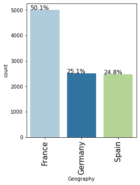

```python
labeled_barplot(bankdf1, "Geography", perc=True)  # barplot
```

Most of the customers are French

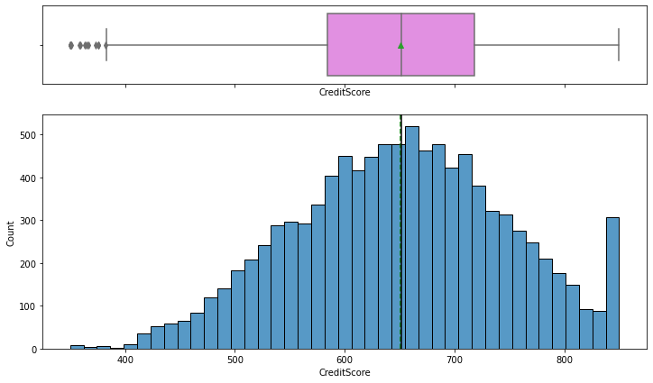

```python
histogram_boxplot(bankdf1, "CreditScore")  # boxplot
```

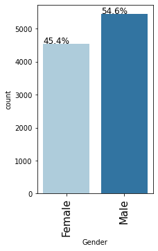

```python
labeled_barplot(bankdf1, "Gender", perc=True)  # barplot
```

There are more male than Female customers

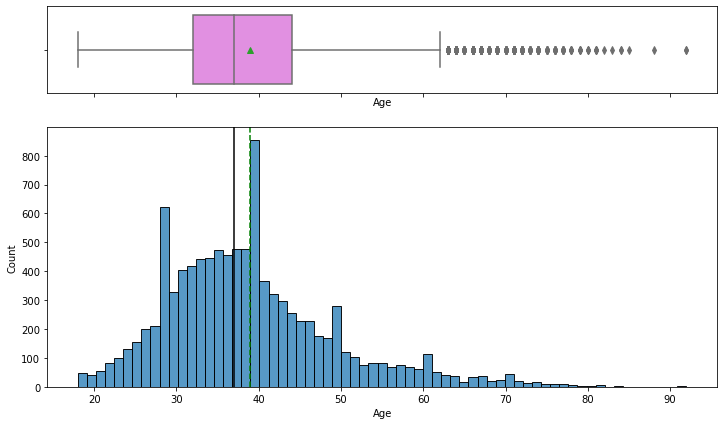

```python
histogram_boxplot(bankdf1, "Age")  # boxplot
```

Age distribution is right skewed There are many outliers in the distribution for this variable

Credit Score distribution is left skewed There are some outliers in the distribution for this variable

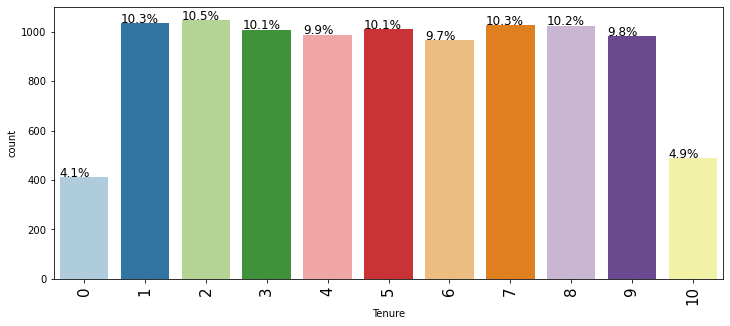

```python
labeled_barplot(bankdf1, "Tenure", perc=True)  # barplot
```

## Data Analysis: Bivariate Analysis

The pair plot between the values in dataset show the overall distribution against each of the columns. This give an overall view against the selected dataset values.

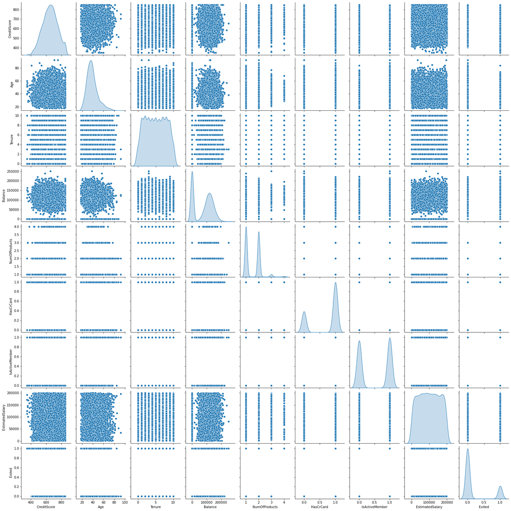

```python
sns.pairplot(bankdf1, diag_kind="kde")
# pair plot multiple pair wise bivariate distributions
```

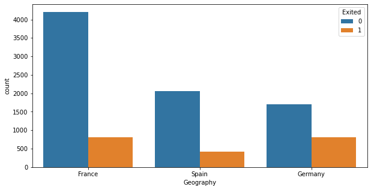

```python
plt.figure(figsize=(10, 5))
sns.countplot(x="Geography", hue="Exited", data=bankdf1)
# plot to assess important variables
```

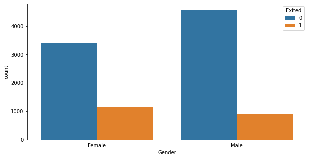

```python
plt.figure(figsize=(10, 5))
sns.countplot(x="Gender", hue="Exited", data=bankdf1)
# plot to assess important variables
```

Percentage of female customers leaving bank are more than male.

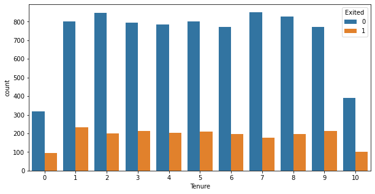

```python
plt.figure(figsize=(10, 5))
sns.countplot(x="Tenure", hue="Exited", data=bankdf1)
# plot to assess important variables
```

There is not much disparity in terms of customers leaving the bank and tenure

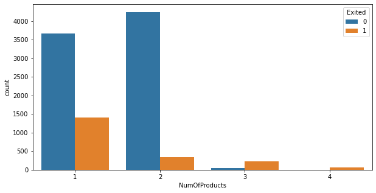

```python
plt.figure(figsize=(10, 5))
sns.countplot(x="NumOfProducts", hue="Exited", data=bankdf1)
# plot to assess important variables
```

Most of the customers have 1 or 2 products. This having 2 products are least likely to leave the bank. If the customers have more than 2 products probability of leaving the bank increases drastically

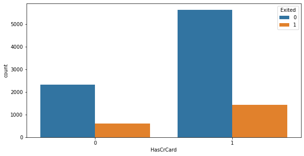

```python
plt.figure(figsize=(10, 5))
sns.countplot(x="HasCrCard", hue="Exited", data=bankdf1)
# plot to assess important variables
```

[figure not shown]

```python
#Histrogram for feature Time
f, (ax1, ax2) = plt.subplots(2, 1, sharex=True, figsize=(12,4))

ax1.hist(bankdf1["EstimatedSalary"][bankdf1["Exited"] == 0], bins = 100)
ax1.set_title('Bank Customer')

ax2.hist(bankdf1["EstimatedSalary"][bankdf1["Exited"] == 1], bins = 100)
ax2.set_title('Exited')

plt.xlabel('Seconds after transaction number zero')
plt.ylabel('Number of Transactions')
plt.show()
```

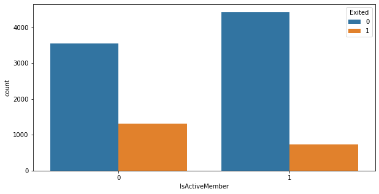

```python
plt.figure(figsize=(10, 5))
sns.countplot(x="IsActiveMember", hue="Exited", data=bankdf1)
# plot to assess important variables
```

The non active members 0 have higher percentage of members leaving the bank

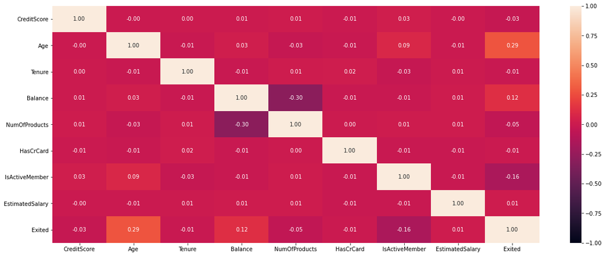

```python
plt.figure(figsize=(20, 8))
sns.heatmap(bankdf1.corr(), annot=True, vmin=-1, vmax=1, fmt=".2f")  # Heatmap
plt.show()
```

### Data Pre-Processing

#### Checking for missing values in the data

```python
bankdf2 = bankdf1.copy()
bankdf2.isnull().sum()
```

```
CreditScore        0
Geography          0
Gender             0
Age                0
Tenure             0
Balance            0
NumOfProducts      0
HasCrCard          0
IsActiveMember     0
EstimatedSalary    0
Exited             0
dtype: int64
```

#### Check for duplicate data

```python
# let's check for duplicate values in the data
bankdf2.duplicated().sum()
```

```
0
```

```python
# convert the numeric values to one-hot code to remove the order
bankdf2 = pd.get_dummies(bankdf2, columns=['Geography'])
bankdf2 = pd.get_dummies(bankdf2, columns=['Gender'])
bankdf2.head(5)
```

|  | CreditScore | Age | Tenure | Balance | NumOfProducts | HasCrCard | IsActiveMember | EstimatedSalary | Exited | Geography_France | Geography_Germany | Geography_Spain | Gender_Female | Gender_Male |
| --- | --- | --- | --- | --- | --- | --- | --- | --- | --- | --- | --- | --- | --- | --- |
| 0 | 619 | 42 | 2 | 0.00 | 1 | 1 | 1 | 101348.88 | 1 | 1 | 0 | 0 | 1 | 0 |
| 1 | 608 | 41 | 1 | 83807.86 | 1 | 0 | 1 | 112542.58 | 0 | 0 | 0 | 1 | 1 | 0 |
| 2 | 502 | 42 | 8 | 159660.80 | 3 | 1 | 0 | 113931.57 | 1 | 1 | 0 | 0 | 1 | 0 |
| 3 | 699 | 39 | 1 | 0.00 | 2 | 0 | 0 | 93826.63 | 0 | 1 | 0 | 0 | 1 | 0 |
| 4 | 850 | 43 | 2 | 125510.82 | 1 | 1 | 1 | 79084.10 | 0 | 0 | 0 | 1 | 1 | 0 |

```python
X_data = bankdf2[['CreditScore','Geography_France','Geography_Germany','Geography_Spain', 'Gender_Female', 'Gender_Male', 'Age',
     'Tenure', 'Balance', 'NumOfProducts', 'HasCrCard',
       'IsActiveMember', 'EstimatedSalary',]]
y_data = bankdf2['Exited']
```

### Scaling of required features

```python
from sklearn.preprocessing import StandardScaler
X_data['normalizedBalance'] = StandardScaler().fit_transform(X_data['Balance'].values.reshape(-1,1))
X_data= X_data.drop(['Balance'],axis=1)
```

```python
from sklearn.preprocessing import StandardScaler
X_data['normalizedEstimatedSalary'] = StandardScaler().fit_transform(X_data['EstimatedSalary'].values.reshape(-1,1))
X_data= X_data.drop(['EstimatedSalary'],axis=1)
```

```python
from sklearn.preprocessing import StandardScaler
X_data['normalizedCreditScore'] = StandardScaler().fit_transform(X_data['CreditScore'].values.reshape(-1,1))
X_data= X_data.drop(['CreditScore'],axis=1)
```

```python
from sklearn.preprocessing import StandardScaler
X_data['normalizedAge'] = StandardScaler().fit_transform(X_data['Age'].values.reshape(-1,1))
X_data= X_data.drop(['Age'],axis=1)
```

```python
X_data.head(5)
```

|  | Geography_France | Geography_Germany | Geography_Spain | Gender_Female | Gender_Male | Tenure | NumOfProducts | HasCrCard | IsActiveMember | normalizedBalance | normalizedEstimatedSalary | normalizedCreditScore | normalizedAge |
| --- | --- | --- | --- | --- | --- | --- | --- | --- | --- | --- | --- | --- | --- |
| 0 | 1 | 0 | 0 | 1 | 0 | 2 | 1 | 1 | 1 | -1.225848 | 0.021886 | -0.326221 | 0.293517 |
| 1 | 0 | 0 | 1 | 1 | 0 | 1 | 1 | 0 | 1 | 0.117350 | 0.216534 | -0.440036 | 0.198164 |
| 2 | 1 | 0 | 0 | 1 | 0 | 8 | 3 | 1 | 0 | 1.333053 | 0.240687 | -1.536794 | 0.293517 |
| 3 | 1 | 0 | 0 | 1 | 0 | 1 | 2 | 0 | 0 | -1.225848 | -0.108918 | 0.501521 | 0.007457 |
| 4 | 0 | 0 | 1 | 1 | 0 | 2 | 1 | 1 | 1 | 0.785728 | -0.365276 | 2.063884 | 0.388871 |

```python
X_train, X_test, y_train, y_test = train_test_split(X_data, y_data, test_size = 0.2, random_state = 7)
```

```python
print(X_train.shape)
print(X_test.shape)
print(y_train.shape)
print(y_test.shape)
```

```
(8000, 13)
(2000, 13)
(8000,)
(2000,)
```

### Model building

```python
#initialize the model
model = Sequential()

# input layer
model.add(Dense(units=16, input_dim = 13,activation='relu'))
# hidden layer
model.add(Dense(units=10,activation='relu'))
#Adding Dropout to prevent overfitting
model.add(Dropout(0.5))
model.add(Dense(10,activation='relu'))
model.add(Dense(10,activation='relu'))
model.add(Dense(1,activation='sigmoid'))
```

#### Model compile : optimizers and loss functions

```python
# Compile the model
model.compile(optimizer='adam',loss='binary_crossentropy',metrics=['accuracy'])
```

```python
model.summary()
```

```
Model: "sequential"
_________________________________________________________________
Layer (type)                 Output Shape              Param #
=================================================================
dense (Dense)                (None, 16)                224
_________________________________________________________________
dense_1 (Dense)              (None, 10)                170
_________________________________________________________________
dropout (Dropout)            (None, 10)                0
_________________________________________________________________
dense_2 (Dense)              (None, 10)                110
_________________________________________________________________
dense_3 (Dense)              (None, 10)                110
_________________________________________________________________
dense_4 (Dense)              (None, 1)                 11
=================================================================
Total params: 625
Trainable params: 625
Non-trainable params: 0
_________________________________________________________________
```

#### Training the Model : Forward pass and Backpropagation

```python
#fitting the model
history=model.fit(X_train,y_train,batch_size=10,epochs=10,validation_split=0.2)
```

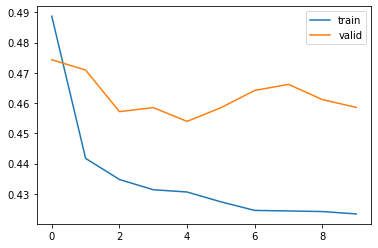

```python
# Capturing learning history per epoch
hist  = pd.DataFrame(history.history)
hist['epoch'] = history.epoch
plt.plot(hist['loss'])
plt.plot(hist['val_loss'])
plt.legend(("train" , "valid") , loc =0)
```

### Model Evaluation

```python
score = model.evaluate(X_test, y_test)
```

```python
print(score)
```

```
[0.44680124521255493, 0.7904999852180481]
```

```python
def make_confusion_matrix(cf,
                          group_names=None,
                          categories='auto',
                          count=True,
                          percent=True,
                          cbar=True,
                          xyticks=True,
                          xyplotlabels=True,
                          sum_stats=True,
                          figsize=None,
                          cmap='Blues',
                          title=None):
    blanks = ['' for i in range(cf.size)]
    if group_names and len(group_names)==cf.size:
        group_labels = ["{}\n".format(value) for value in group_names]
    else:
        group_labels = blanks
    if count:
        group_counts = ["{0:0.0f}\n".format(value) for value in cf.flatten()]
    else:
        group_counts = blanks
    if percent:
        group_percentages = ["{0:.2%}".format(value) for value in cf.flatten()/np.sum(cf)]
    else:
        group_percentages = blanks
    box_labels = [f"{v1}{v2}{v3}".strip() for v1, v2, v3 in zip(group_labels,group_counts,group_percentages)]
    box_labels = np.asarray(box_labels).reshape(cf.shape[0],cf.shape[1])
    if sum_stats:
        accuracy  = np.trace(cf) / float(np.sum(cf))
        if len(cf)==2:
            precision = cf[1,1] / sum(cf[:,1])
            recall    = cf[1,1] / sum(cf[1,:])
            f1_score  = 2*precision*recall / (precision + recall)
            stats_text = "\n\nAccuracy={:0.3f}\nPrecision={:0.3f}\nRecall={:0.3f}\nF1 Score={:0.3f}".format(
                accuracy,precision,recall,f1_score)
        else:
            stats_text = "\n\nAccuracy={:0.3f}".format(accuracy)
    else:
        stats_text = ""
    if figsize==None:
        figsize = plt.rcParams.get('figure.figsize')
    if xyticks==False:
        categories=False
    plt.figure(figsize=figsize)
    sns.heatmap(cf,annot=box_labels,fmt="",cmap=cmap,cbar=cbar,xticklabels=categories,yticklabels=categories)

    if xyplotlabels:
        plt.ylabel('True label')
        plt.xlabel('Predicted label' + stats_text)
    else:
        plt.xlabel(stats_text)
    if title:
        plt.title(title)
```

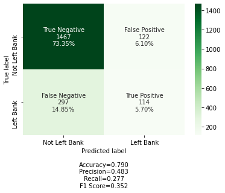

```python
## Confusion Matrix
import seaborn as sn
y_pred1 = model.predict(X_test)
for i in range(len(y_test)):
    if y_pred1[i]>0.5:
        y_pred1[i]=1
    else:
        y_pred1[i]=0
cm2=confusion_matrix(y_test, y_pred1)
labels = ['True Negative','False Positive','False Negative','True Positive']
categories = [ 'Not Left Bank','Left Bank']
make_confusion_matrix(cm2,
                      group_names=labels,
                      categories=categories,
                      cmap='Greens')
```

```python
from sklearn.utils import class_weight
class_weights = class_weight.compute_class_weight('balanced', np.unique(y_train), np.array([y_train.iloc[i] for i in range(len(y_train))]))
class_weights = dict(enumerate(class_weights))
class_weights
```

```
{0: 0.627549419516787, 1: 2.4600246002460024}
```

```python
model.fit(X_train,y_train,batch_size=15,epochs=5, class_weight=class_weights, shuffle=True)
```

```
<keras.callbacks.History at 0x1fc94991100>
```

```python
score_weighted = model.evaluate(X_test, y_test)
```

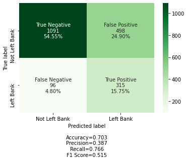

```python
## Confusion Matrix on unsee test set
import seaborn as sn
y_pred1 = model.predict(X_test)
for i in range(len(y_test)):
    if y_pred1[i]>0.5:
        y_pred1[i]=1
    else:
        y_pred1[i]=0
cm2=confusion_matrix(y_test, y_pred1)
labels = ['True Negative','False Positive','False Negative','True Positive']
categories = [ 'Not Left Bank','Left Bank']
make_confusion_matrix(cm2,
                      group_names=labels,
                      categories=categories,
                      cmap='Greens')
```

```python
#initialize the model
model1 = Sequential()
model1.add(Dense(units=16, input_dim = 13,activation='relu'))
model1.add(Dense(units=10,activation='relu'))
model1.add(Dropout(0.5)) #Adding Dropout to prevent overfitting
model1.add(Dense(10,activation='relu'))
model1.add(Dense(10,activation='relu'))
model1.add(Dense(1,activation='sigmoid'))
```

```python
# Compile the model
model1.compile(optimizer='adam',loss='binary_crossentropy',metrics=['accuracy'])
```

```python
model1.summary()
```

```
Model: "sequential_1"
_________________________________________________________________
Layer (type)                 Output Shape              Param #
=================================================================
dense_5 (Dense)              (None, 16)                224
_________________________________________________________________
dense_6 (Dense)              (None, 10)                170
_________________________________________________________________
dropout_1 (Dropout)          (None, 10)                0
_________________________________________________________________
dense_7 (Dense)              (None, 10)                110
_________________________________________________________________
dense_8 (Dense)              (None, 10)                110
_________________________________________________________________
dense_9 (Dense)              (None, 1)                 11
=================================================================
Total params: 625
Trainable params: 625
Non-trainable params: 0
_________________________________________________________________
```

```python
#fitting the model
history=model1.fit(X_train,y_train,batch_size=20,epochs=75,validation_split=0.2)
```

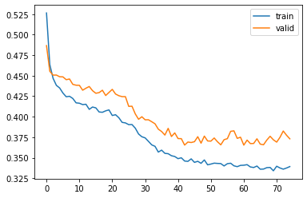

```python
# Capturing learning history per epoch
hist  = pd.DataFrame(history.history)
hist['epoch'] = history.epoch
plt.plot(hist['loss'])
plt.plot(hist['val_loss'])
plt.legend(("train" , "valid") , loc =0)
```

```python
score = model.evaluate(X_test, y_test)
```

```python
print(score)
```

```
[0.6547967195510864, 0.703000009059906]
```

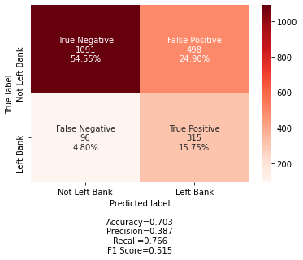

```python
## Confusion Matrix on unsee test set
import seaborn as sn
y_pred1 = model.predict(X_test)
for i in range(len(y_test)):
    if y_pred1[i]>0.5:
        y_pred1[i]=1
    else:
        y_pred1[i]=0



cm2=confusion_matrix(y_test, y_pred1)
labels = ['True Negative','False Positive','False Negative','True Positive']
categories = [ 'Not Left Bank','Left Bank']
make_confusion_matrix(cm2,
                      group_names=labels,
                      categories=categories,
                      cmap='Reds')
```

```python
#initialize the model
model2 = Sequential()

# input layer
model2.add(Dense(units=16, input_dim = 13,activation='relu'))
# hidden layer
model2.add(Dense(units=10,kernel_initializer='he_normal',activation='relu'))
#Adding Dropout to prevent overfitting
model2.add(Dropout(0.5))
model2.add(Dense(10,kernel_initializer='he_normal',activation='relu'))
model2.add(Dense(10,kernel_initializer='he_normal', activation='relu'))
model2.add(Dense(1,kernel_initializer='he_normal',activation='sigmoid'))
```

```python
# Compile the model
model2.compile(Adam(lr=0.001), loss='binary_crossentropy', metrics=['accuracy'])
```

```python
model2.summary()
```

```
Model: "sequential_2"
_________________________________________________________________
Layer (type)                 Output Shape              Param #
=================================================================
dense_10 (Dense)             (None, 16)                224
_________________________________________________________________
dense_11 (Dense)             (None, 10)                170
_________________________________________________________________
dropout_2 (Dropout)          (None, 10)                0
_________________________________________________________________
dense_12 (Dense)             (None, 10)                110
_________________________________________________________________
dense_13 (Dense)             (None, 10)                110
_________________________________________________________________
dense_14 (Dense)             (None, 1)                 11
=================================================================
Total params: 625
Trainable params: 625
Non-trainable params: 0
_________________________________________________________________
```

```python
#fitting the model
hist_mod2=model2.fit(X_train,y_train,batch_size=50,epochs=50,validation_split=0.2)
```

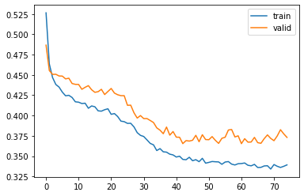

```python
# Capturing learning history per epoch
hist_mod2  = pd.DataFrame(history.history)
hist_mod2['epoch'] = history.epoch
plt.plot(hist_mod2['loss'])
plt.plot(hist_mod2['val_loss'])
plt.legend(("train" , "valid") , loc =0)
```

```python
print(score)
```

```
[0.6547967195510864, 0.703000009059906]
```

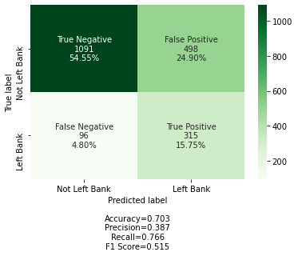

```python
## Confusion Matrix
import seaborn as sn
y_pred1 = model.predict(X_test)
for i in range(len(y_test)):
    if y_pred1[i]>0.5:
        y_pred1[i]=1
    else:
        y_pred1[i]=0
cm2=confusion_matrix(y_test, y_pred1)
labels = ['True Negative','False Positive','False Negative','True Positive']
categories = [ 'Not Left Bank','Left Bank']
make_confusion_matrix(cm2,
                      group_names=labels,
                      categories=categories,
                      cmap='Greens')
```

### Conclusion

Three different models were tried with different tuning parameters.